# ML_Project

Keith Maclaren

Friday, June 19, 2015

# Summary

In this assignment, we are asked to predict the quality of the person’s movement based on activity data collected from accelerometers. These can be attached to devices such as Fitbits, and other off-the-shelf devices on the market today. We are provided with training & test data to build a predictive model.

```r
library(AppliedPredictiveModeling)
library(caret)
library(rattle)
library(rpart)

traindf <- read.csv("pml-training.csv")
testdf <- read.csv("pml-testing.csv")
```

# Pre-Processing

Based on the data provided, I will ensure all useful data elements are cast to numeric types for the random forest to be most efficient and pre-process out the first few variables to avoid overfitting on username or date.

```r
dim(traindf)
```

```
## [1] 19622   160
```

```r
dim(testdf)
```

```
## [1]  20 160
```

```r
# pre-processing
traindf[,7:159] <- sapply(traindf[,7:159],as.numeric)
testdf[,7:159] <- sapply(testdf[,7:159], as.numeric)


## feature extraction & selection

# disregard user names, dates, other metadata that doesn't help the model
traindf <- traindf[8:160]
testdf <- testdf[8:160]
```

# Approach

Since we don’t know which variables are good predictors, a viable model to test is Random Forest because it uses a random set of predictors and testing several models (ensemble) through an n-fold validation.

I will break up the training data into 70% model building, and 30% for cross validation. The Train Control parameters allow me to set the number of folds to 3.

```r
set.seed(125)

# since test set only contains 20 observations,
# remove features that contain NAs from test set
isna <- is.na(apply(testdf,2,sum))

testdf <- testdf[,!isna]
dim(testdf)
```

```
## [1] 20 53
```

```r
traindf <- traindf[,!isna]

# create validation data set using Train
inTrain <- createDataPartition(y=traindf$classe, p=0.7, list=FALSE)
subtraindf <- traindf[inTrain,]
cvdf <- traindf[-inTrain,]
rm(inTrain,isna,traindf)

modFit <- train(classe ~ ., method = "rf",
                data = subtraindf, importance = T,
                trControl = trainControl(method = "cv", number = 3))
```

```r
vi <- varImp(modFit)
vi$importance[1:10,]
```

```
##                          A         B         C         D          E
## roll_belt        71.811896 93.663507 83.442176 82.202056 100.000000
## pitch_belt       29.551737 95.348987 60.523267 45.516960  39.806098
## yaw_belt         64.876854 63.622230 65.189703 68.635482  50.298940
## total_accel_belt  0.000000  6.625010  5.494299  2.537705   1.982985
## gyros_belt_x     22.697277  7.758940 16.009934  5.864237  11.093433
## gyros_belt_y      1.793267  9.551892 11.954226  9.590180  13.985657
## gyros_belt_z     20.458474 27.785039 34.108584 21.576125  40.869935
## accel_belt_x      3.443706  7.912869  8.136628  3.289628   8.498683
## accel_belt_y      1.938368  9.958673  7.756318  6.021282   1.634063
## accel_belt_z     12.357771 21.448258 19.395302 16.626503  13.288505
```

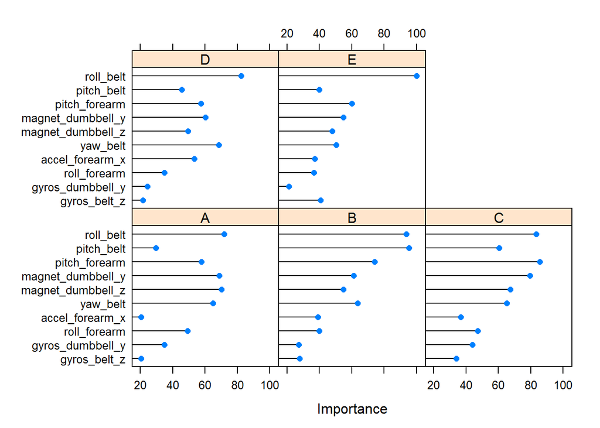

```r
plot(varImp(modFit), top = 10)
```

And the confusion matrix on the 30% of the training data not used to build the model shows the accuracy is over 99%, which means the out-of-sample error rate is less than 1%:

```r
predcv <- predict(modFit, cvdf)
cm <- confusionMatrix(predcv, cvdf$classe)
print(cm)
```

```
## Confusion Matrix and Statistics
##
##           Reference
## Prediction    A    B    C    D    E
##          A 1673    7    0    0    0
##          B    0 1129    7    0    1
##          C    1    3 1012   11    4
##          D    0    0    7  952    2
##          E    0    0    0    1 1075
##
## Overall Statistics
##
##                Accuracy : 0.9925
##                  95% CI : (0.99, 0.9946)
##     No Information Rate : 0.2845
##     P-Value [Acc > NIR] : < 2.2e-16
##
##                   Kappa : 0.9905
##  Mcnemar's Test P-Value : NA
##
## Statistics by Class:
##
##                      Class: A Class: B Class: C Class: D Class: E
## Sensitivity            0.9994   0.9912   0.9864   0.9876   0.9935
## Specificity            0.9983   0.9983   0.9961   0.9982   0.9998
## Pos Pred Value         0.9958   0.9930   0.9816   0.9906   0.9991
## Neg Pred Value         0.9998   0.9979   0.9971   0.9976   0.9985
## Prevalence             0.2845   0.1935   0.1743   0.1638   0.1839
## Detection Rate         0.2843   0.1918   0.1720   0.1618   0.1827
## Detection Prevalence   0.2855   0.1932   0.1752   0.1633   0.1828
## Balanced Accuracy      0.9989   0.9948   0.9912   0.9929   0.9967
```

# Further Analysis:

Plots to show how the random forest converges:

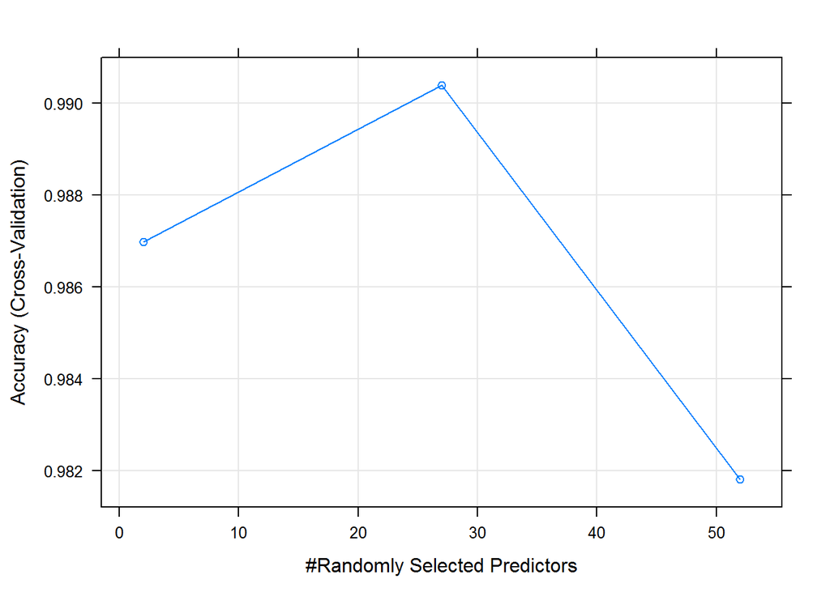

```r
plot(modFit)
```

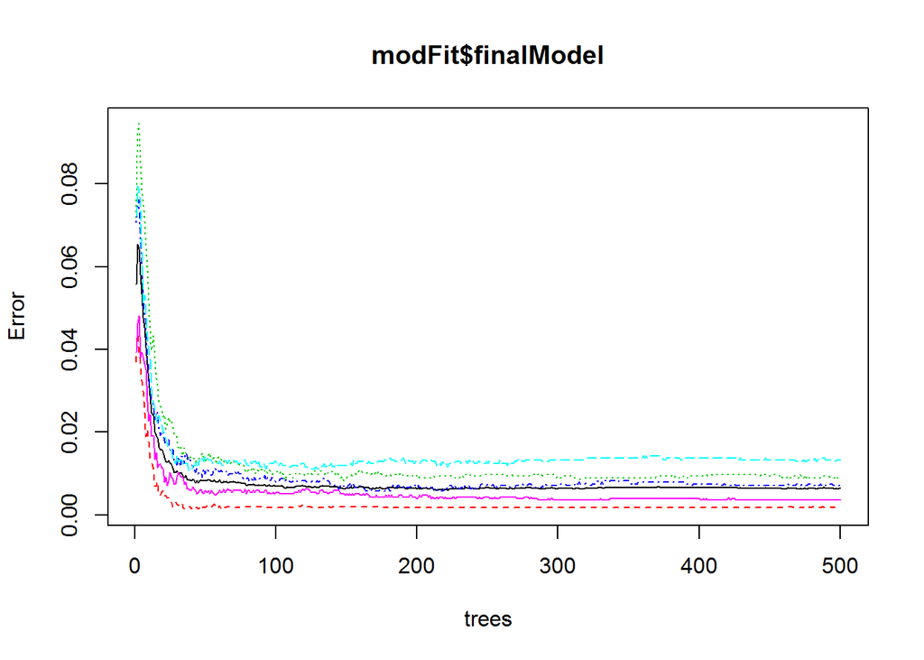

```r
plot(modFit$finalModel)
```

And now to predict the classe value for the test set:

```r
testdf$classe <- predict(modFit, testdf)
head(testdf, 20)
```

```
##    roll_belt pitch_belt yaw_belt total_accel_belt gyros_belt_x
## 1     123.00      27.00    -4.75               20        -0.50
## 2       1.02       4.87   -88.90                4        -0.06
## 3       0.87       1.82   -88.50                5         0.05
## 4     125.00     -41.60   162.00               17         0.11
## 5       1.35       3.33   -88.60                3         0.03
## 6      -5.92       1.59   -87.70                4         0.10
## 7       1.20       4.44   -87.30                4        -0.06
## 8       0.43       4.15   -88.50                4        -0.18
## 9       0.93       6.72   -93.70                4         0.10
## 10    114.00      22.40   -13.10               18         0.14
## 11      0.92       5.94   -92.70                3         0.05
## 12      1.01       4.96   -87.80                5        -0.10
## 13      0.54       2.45   -88.60                3        -0.06
## 14      0.45       5.02   -87.90                5        -0.05
```

[output cut: 237 more lines]

And then output the predicted values to files to submit for part 2 of the assignment:

```r
testdf$classe <- as.character(predict(modFit, testdf))

# write prediction files
pml_write_files = function(x){
        n = length(x)
        for(i in 1:n){
                filename = paste0("./predict/problem_id_", i, ".txt")
                write.table(x[i], file = filename, quote = FALSE, row.names = FALSE, col.names = FALSE)
        }
}

pml_write_files(testdf$classe)
```